Josep Reverter Sancho 18/11/2024

# Data Analysis Test - Stolen Motorbikes

The Product Management in M wants to know about the situation of stolen motorbikes in Spain during the last years to decide whether to push forward a functionality that will help motorbike riders find a stolen motorbike.

The data about stolen motorbikes in Spain is publicly available in the DGT website. Our Data Engineering team has already done the extraction job and has provided us with a dataset (see the file stolen_motorbikes_dgt.csv) including the following fields:

• registration_date: when the motorbike was first registered (we will assume this is when it was first bought)

• stolen_date: when the motorbike was stolen

• brand: brand of the motorbike

• model: model of the motorbike (note the number indicates de engine CC)

• province: spanish province where the motorbike was registered

Product management needs answers to these questions:

• Are there less stolen motorbikes now than 5 years ago?

• Is there any brand that gets stolen more?

• Do we know if expensive bikes are stolen more often?

• What about the location of the stolen motorbikes?

Even if these are the questions that the product team came up with, feel free to explore the data and provide additional insights that you find.

```python
import pandas as pd
from io import StringIO
import matplotlib.pyplot as plt
import numpy as np
```

```python
# As the data in the csv has some characters that makes conflicts ('"'), a simple pd.read_csv can not be done.
# We have to read with pain text and then clean the data before doing the read_csv, instead.
with open('stolen_motorbikes_dgt(in).csv', 'r') as file:
    data = file.read()

cleaned_data = data.replace('""', '').replace('"', '').strip()
df = pd.read_csv(StringIO(cleaned_data), delimiter=',')

df["registration_date"] = pd.to_datetime(df["registration_date"])
df["stolen_date"] = pd.to_datetime(df["stolen_date"])

df.head()
```

|  | registration_date | stolen_date | brand | model | province |
| --- | --- | --- | --- | --- | --- |
| 0 | 2005-06-23 | 2017-01-01 | HONDA | SH125 | M |
| 1 | 2015-11-02 | 2017-01-01 | HONDA | ANC125 | B |
| 2 | 2011-05-06 | 2017-01-01 | YAMAHA | YP125R | SS |
| 3 | 1995-05-12 | 2017-01-01 | HONDA | NH 90 | GR |
| 4 | 2011-02-09 | 2017-01-01 | S.Y.M | GTS 125 EVO | CE |

As we know, we are in November 2022 (according to the latest data we have) and we need to analyze the data of stolen motorcycles of the last 5 years, to provide information and **help the business department to make decisions** on whether to release a functionality to facilitate finding stolen motorcycles.

For this we have information about the date of purchase, the date of theft, the brand, the model, and the province where the motorcycle was stolen.

The study consists of **4 parts** where the thefts are analyzed with different approaches:

1. Date
2. Brand and Model
3. Price
4. Location

In each part are drawn valuable conclusions, not only to decide **whether to take the functionality out or not**, but also to decide **how to design it and how it will interact with the user**. Each part of the study has its **part of code** and pre-processing (in which the comments are in the code itself), and its part of **graphics and conclusions**.

## 1. Date

```python
# create useful features extracted from dates
df["stolen_year"] = df["stolen_date"].dt.year
df["stolen_month"] = df["stolen_date"].dt.month
df["stolen_day"] = df["stolen_date"].dt.weekday
df["stolen_day_name"] = df["stolen_date"].dt.day_name()
df["years_to_stole"] = (df["stolen_date"] - df["registration_date"]).dt.days / 365.25

# brand - model feature
df["brand_model"] = df["brand"] + " - " + df["model"]

print(f"We have data of stolen motorbikes from {min(df.stolen_date)} to {max(df.stolen_date)}.")
```

```
We have data of stolen motorbikes from 2017-01-01 00:00:00 to 2022-11-30 00:00:00.
```

```python
# only comparing till the 21st of october of the two years
df_stolen_2022 = df[(df["stolen_date"]<=pd.to_datetime('2022-11-30')) & (df["stolen_year"]==2022)]
df_stolen_2017 = df[(df["stolen_date"]<=pd.to_datetime('2017-11-30')) & (df["stolen_year"]==2017)]

print(f"Stolen Motorbikes in 2022: {len(df_stolen_2022)}")
print(f"Stolen Motorbikes in 2017: {len(df_stolen_2017)}")
print(f"The growth of the stolen motorbikes between the 2017 and 2022 (from January to november) represents a growth of {((len(df_stolen_2022) - len(df_stolen_2017))/len(df_stolen_2017))*100:.1f}%")
```

```
Stolen Motorbikes in 2022: 5908
Stolen Motorbikes in 2017: 6686
The growth of the stolen motorbikes between the 2017 and 2022 (from January to november) represents a growth of -11.6%
```

To get an idea of where motorcycle thefts stand right now, we have compared the number of thefts in the first year with data, with the number of thefts in the current year (2022).

As for the current year we only have data until November (30-11-2022), the correct thing to do is to compare it with only the **2017 data prior to the 30th of November**.

The result we have is that the **number of thefts** in 2022 is lower than in 2017. Specifically, it **has decreased by 11.6%**.

This is a useful insight to know how the situation is today, but to have a better context, it is better to **see the amount of thefts year by year**, and study if there is any temporal trend.

|  | stolen_year | count | pct_growth |
| --- | --- | --- | --- |
| 1 | 2017 | 7281 | NaN |
| 0 | 2018 | 7548 | 3.667079 |
| 2 | 2019 | 7179 | -4.888712 |
| 4 | 2020 | 4895 | -31.815016 |
| 5 | 2021 | 4405 | -10.010215 |
| 3 | 2022 | 5908 | 34.120318 |

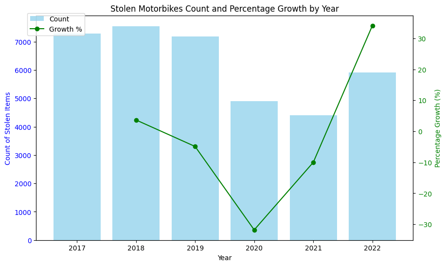

```python
# create a dataframe with the number of stolen motorbikes by year
stolen_years_progression = pd.DataFrame(df["stolen_year"].value_counts()).reset_index().sort_values(by="stolen_year")
stolen_years_progression["pct_growth"] = stolen_years_progression["count"].pct_change()*100
display(stolen_years_progression)

# plotting
fig, ax1 = plt.subplots(figsize=(10, 6))

ax1.bar(stolen_years_progression['stolen_year'], stolen_years_progression['count'], color='skyblue', alpha=0.7, label='Count')
ax1.set_xlabel('Year')
ax1.set_ylabel('Count of Stolen Items', color='blue')
ax1.tick_params(axis='y', labelcolor='blue')
ax1.set_title('Stolen Motorbikes Count and Percentage Growth by Year')

ax2 = ax1.twinx()
ax2.plot(stolen_years_progression['stolen_year'], stolen_years_progression['pct_growth'], color='green', marker='o', label='Growth %')
ax2.set_ylabel('Percentage Growth (%)', color='green')
ax2.tick_params(axis='y', labelcolor='green')

fig.legend(loc="upper left", bbox_to_anchor=(0.1, 0.9))

plt.show()
```

In the above graph we see the **evolution** of thefts **in every full year** (without filtering by date prior to November), along with the **growth** with respect to the **previous year**.

We see that in the years 2017, 2018 and 2019, the amount was very high with respect to 2020 and 2021, which makes sense, since these years were pandemic years due to Covid-19, and t**hefts were affected by restrictions on schedules, police presence and control, and the low purchase of new motorcycles by users**.

A very important fact is that **in 2022 there has been the highest growth** over the previous year in the last 5 years, specifically **34.12%** (and that is with one month left to the end of the year).

Hence, although at first it might seem that steals are decreasing over time (with a decrease of 11.6% from 2017 to 2022), this is not the case. And it is rather the opposite in recent years.

Here we have the first evidence that **M's functionality would be much needed for users**, as the number of thefts has risen again, and we assume that this will also happen with the preoccupation of customers.

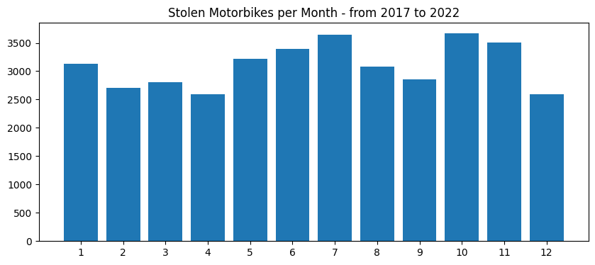

```python
# create a dataframe with the number of stolen motorbikes by month
df_stolen_months = pd.DataFrame(df[["stolen_month"]].value_counts()).reset_index().sort_values(by="stolen_month")

# plotting
fig, ax = plt.subplots(figsize=(10, 4))
ax.bar(df_stolen_months["stolen_month"], df_stolen_months["count"])
ax.set_xticks(df_stolen_months["stolen_month"])
ax.set_title("Stolen Motorbikes per Month - from 2017 to 2022")

plt.show()
```

To see any kind of **seasonality** in the robberies, we can see in the graph its distribution by months.

No relevant conclusions have been drawn from this graph, other than a slight increase in June, July, October and November (considering that data from December 2022 is missing).

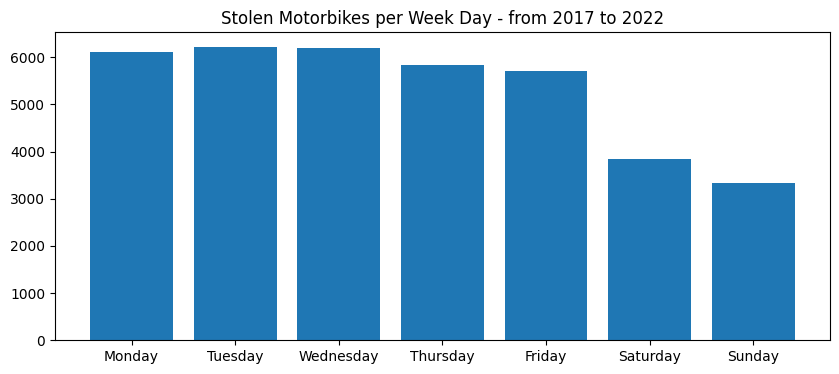

```python
# create a dataframe with the number of stolen motorbikes per day
df_stolen_weekdays = pd.DataFrame(df[["stolen_day_name", "stolen_day"]].value_counts()).reset_index().sort_values(by="stolen_day")

# plotting
fig, ax = plt.subplots(figsize=(10, 4))
ax.bar(df_stolen_weekdays["stolen_day_name"], df_stolen_weekdays["count"])
ax.set_xticks(df_stolen_weekdays["stolen_day_name"])
ax.set_title("Stolen Motorbikes per Week Day - from 2017 to 2022")

plt.show()
```

The graph showing the distribution of motorcycle **thefts by day of the week** gives us **information to understand how these thefts take place**.

As we can see, there is a clear difference between the number of thefts on weekdays and on weekends. This is due to the fact that **on weekdays there is a large increase in the use of motorcycles** to get from home to work, as well as predictable schedules, more crowded spaces, less vigilance, and the possibility that users have private parking at home, but not at work.

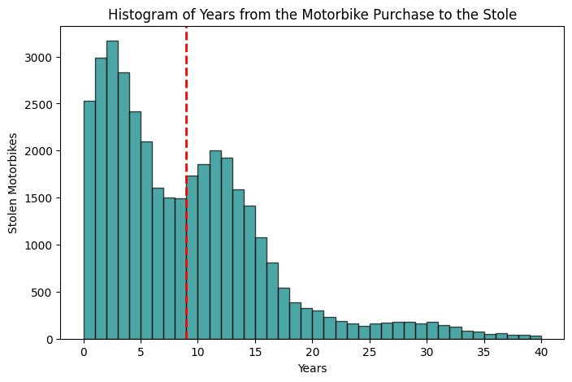

```python
# filtering dataframe to simplify the histogram
df_years_to_stole = df[df["years_to_stole"]<=40]

# plotting
plt.figure(figsize=(8, 5))
plt.hist(df_years_to_stole["years_to_stole"], bins=40, color='teal', alpha=0.7, edgecolor='black')
mean_value = np.mean(df_years_to_stole["years_to_stole"])
plt.axvline(mean_value, color='red', linestyle='dashed', linewidth=2, label=f'Mean = {mean_value:.2f}')
plt.xlabel("Years")
plt.ylabel("Stolen Motorbikes")
plt.title("Histogram of Years from the Motorbike Purchase to the Stole")
plt.show()
```

Another curious insight is the **age of motorcycles** when they are stolen.

At first glance, one might think that the histogram should follow a downward trend since newer motorcycles should be stolen more frequently, as they are more attractive to thieves. However, as shown in the histogram, **motorcycles from 0 to 1 year, and 1 to 2 years, are stolen less than those aged 2 to 3 years**.

This phenomenon has some logic. **A motorcycle being 0 to 2 years old in 2022 means it was purchased in 2022, 2021, or 2020**. Since 2021 and 2020 were marked by the Covid-19 pandemic, **motorcycle sales were likely lower**, making it understandable that in 2022, thefts of motorcycles aged 0 to 2 years are below normal.

On the other hand, what we observe could make sense since we can assume that **users are more careful with their motorcycles in the initial years**, thereby reducing the likelihood of theft.

Another interesting observation is that **thefts rise significantly for motorcycles older than 10 years**. This could be due to various reasons: the release of a motorcycle model between 2013 and 2008 that was highly prone to theft, outdated anti-theft technology in these older models, or less vigilance from their owners.

## 2. Brand and Model

In this section, we will examine motorcycle thefts by brand and model, along with the percentage each brand and model represents of the total thefts, the average age of the motorcycles by brand and model, and the growth in thefts from 2021, also by brand and model.

```python
# creating a dataframe containing the number of stolen motorbikes per brand and average of antiquity
df_brand = df.groupby('brand')['years_to_stole'].agg(["count", "mean"]).reset_index().sort_values(by="count", ascending=False).rename(columns={"count":"stolen_complete", "mean":"average_years_to_stole"})
df_stolen_2021 = df[(df["stolen_date"]<=pd.to_datetime('2021-11-30')) & (df["stolen_year"]==2021)]

# creating dataframes with the number of stolen motorbikes in 2022 and 2021 per brand
df_stolen_2021_brand = pd.DataFrame(df_stolen_2021["brand"].value_counts()).reset_index().rename(columns={"count":"stolen_2021"})
df_stolen_2022_brand = pd.DataFrame(df_stolen_2022["brand"].value_counts()).reset_index().rename(columns={"count":"stolen_2022"})

# merging dataframes to have the 3 images
df_brand = pd.merge(df_brand, df_stolen_2021_brand, on="brand", how="inner")
df_brand = pd.merge(df_brand, df_stolen_2022_brand, on="brand", how="inner")

# creating the growth value between 2022 and 2021
df_brand["growth"] = ((df_brand["stolen_2022"] - df_brand["stolen_2021"]) / df_brand["stolen_2021"]) * 100
df_brand = df_brand.sort_values(by="stolen_complete", ascending=False)

# percentage of stolen motorbikes of the brand comparing with the total
df_brand["percentage_ratio_all"] = (df_brand["stolen_complete"] / np.sum(df_brand["stolen_complete"])) * 100

# filtering only the 30% of most stolen brands
p70 = np.percentile(df_brand.stolen_complete, q=70)
df_brand = df_brand[df_brand["stolen_complete"]>p70]
```

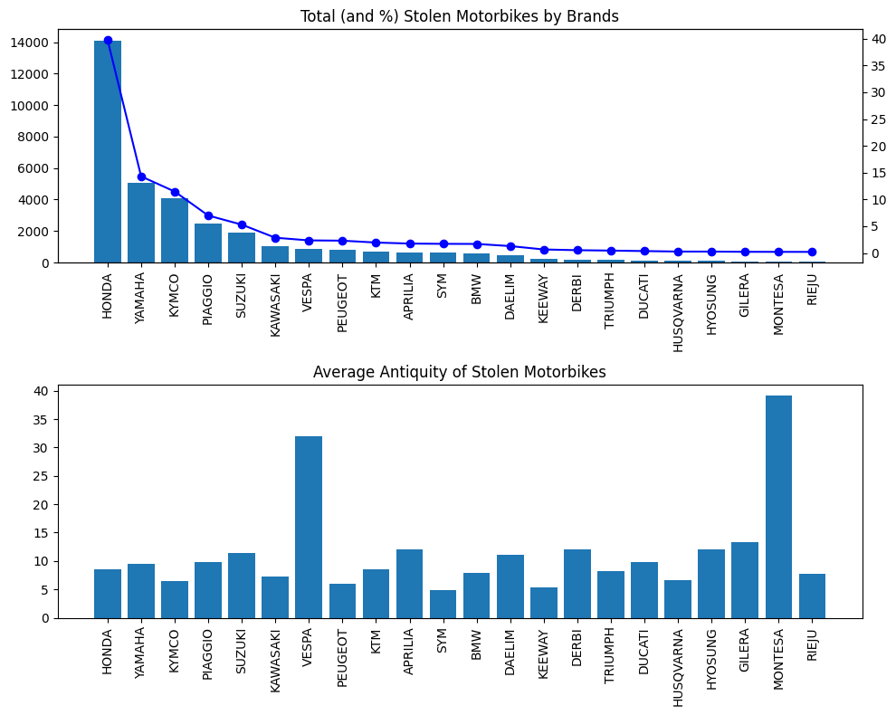

```python
# plotting
def plot_count_and_average_antiquity_by_dimension(data, dimension: str, value1:str, value2:str, value3:str):
    '''
    inputs:
    - data: DataFrame containing all necessary variables
    - dimension: descriptive variable to use as a dimension
    - value1: name of variable to show in the first plot
    - value2: name of variable to show in the right axis of the first plot
    - value3: name of variable to show in the second plot
    '''
    fig, ax1 = plt.subplots(nrows=2, ncols=1, figsize=(10, 8))

    ax1[0].bar(data[dimension], data[value1])
    ax1[0].set_xticks(data[dimension])
    ax1[0].set_title("Total (and %) Stolen Motorbikes by Brands")
    ax1[0].set_xticklabels(data[dimension], rotation=90)

    ax2 = ax1[0].twinx()
    ax2.plot(data[dimension], data[value2], color='b', marker='o', linestyle='-', label='Growth (%)')

    ax1[1].bar(data[dimension], data[value3])
    ax1[1].set_xticks(data[dimension])
    ax1[1].set_title("Average Antiquity of Stolen Motorbikes")
    ax1[1].set_xticklabels(data[dimension], rotation=90)

    fig.tight_layout()
    plt.show()

plot_count_and_average_antiquity_by_dimension(df_brand, dimension="brand", value1="stolen_complete", value2="percentage_ratio_all", value3="average_years_to_stole")
```

As we can see, **Honda has the vast majority of thefts (40% of the total)**, with more than the double compared to the second and third-ranked brands: Yamaha and Kymco.

It is important to note that **these brands also hold a significant Market Share**, which may explain why they experience more thefts.

To draw more precise conclusions, it would be useful to **have data of all registered motorbikes by brand**. This would allow us to **calculate the proportion of stolen motorbikes relative to the total ones** in circulation, providing a much more accurate metric.

Nevertheless, what interests us is the number of users we can impact, and if we develop the M functionality, we should be **particularly focused on ensuring Honda customers are also our customers**.

Regarding age, no clear conclusions can be drawn. The only observation is that Vespa and Montesa motorbikes have the highest average age. This is likely because these brands are the most prevalent among older motorbikes.

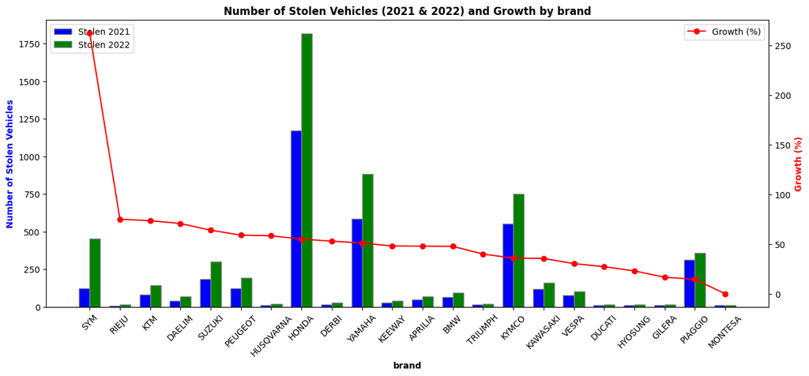

```python
df_sorted = df_brand.sort_values(by="growth", ascending=False)

def plot_count_and_growth_by_dimension(data, dimension:str):

    fig, ax1 = plt.subplots(figsize=(15, 6))

    # Bar plot for stolen counts
    bar_width = 0.35
    r1 = range(len(data))
    r2 = [x + bar_width for x in r1]

    ax1.bar(r1, data['stolen_2021'], color='b', width=bar_width, edgecolor='grey', label='Stolen 2021')
    ax1.bar(r2, data['stolen_2022'], color='g', width=bar_width, edgecolor='grey', label='Stolen 2022')

    # Setting labels and title for left y-axis (bar plot)
    ax1.set_xlabel(dimension, fontweight='bold')
    ax1.set_ylabel('Number of Stolen Vehicles', fontweight='bold', color='b')
    ax1.set_xticks([r + bar_width / 2 for r in range(len(data))])
    ax1.set_xticklabels(data[dimension], rotation=45)
    ax1.legend(loc='upper left')

    # Creating a secondary axis for the growth line plot
    ax2 = ax1.twinx()
    ax2.plot([x + bar_width / 2 for x in r1], data['growth'], color='r', marker='o', linestyle='-', label='Growth (%)')
    ax2.set_ylabel('Growth (%)', fontweight='bold', color='r')
    ax2.legend(loc='upper right')

    plt.title(f'Number of Stolen Vehicles (2021 & 2022) and Growth by {dimension}', fontweight='bold')
    plt.show()

plot_count_and_growth_by_dimension(df_sorted, dimension="brand")
```

When examining the growth in thefts by brand between 2021 and 2022, we still see that **Honda stands out with the highest number of thefts by a big margin**. However, **SYM shows the most significant growth**.

This could be due to SYM gaining a considerable Market Share over the past year, which is why it would also be useful to know the number of registrations in 2021.

Similarly, SYM users are strong candidates for utilizing our functionality.

```python
# doiing same data processing than before but now with brand and model
df_model = pd.DataFrame(df["brand_model"].value_counts()).reset_index().rename(columns={"count":"stolen_complete"})
df_stolen_2021 = df[(df["stolen_date"]<=pd.to_datetime('2021-11-30')) & (df["stolen_year"]==2021)]

df_stolen_2021_model = pd.DataFrame(df_stolen_2021["brand_model"].value_counts()).reset_index().rename(columns={"count":"stolen_2021"})
df_stolen_2022_model = pd.DataFrame(df_stolen_2022["brand_model"].value_counts()).reset_index().rename(columns={"count":"stolen_2022"})

df_model = pd.merge(df_model, df_stolen_2021_model, on="brand_model", how="inner")
df_model = pd.merge(df_model, df_stolen_2022_model, on="brand_model", how="inner")

df_model["growth"] = ((df_model["stolen_2022"] - df_model["stolen_2021"]) / df_model["stolen_2021"]) * 100
df_model = df_model.sort_values(by="stolen_complete", ascending=False)

df_model["percentage_ratio_all"] = (df_model["stolen_complete"] / np.sum(df_model["stolen_complete"])) * 100

p70 = np.percentile(df_model.stolen_complete, q=90)
df_model = df_model[df_model["stolen_complete"]>p70]
```

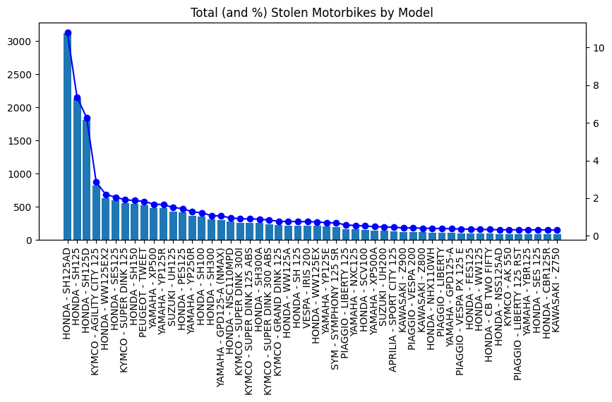

```python
# plotting
fig, ax1 = plt.subplots(figsize=(10, 4))
ax1.bar(df_model["brand_model"], df_model["stolen_complete"])
ax1.set_xticks(df_model["brand_model"])
ax1.set_title("Total (and %) Stolen Motorbikes by Model")
plt.xticks(rotation=90)
ax2 = ax1.twinx()
ax2.plot(df_model["brand_model"], df_model["percentage_ratio_all"], color='b', marker='o', linestyle='-', label='Growth (%)')
plt.show()
```

If we look at thefts by model, it confirms the information previously highlighted. The HONDA - SH125AD, HONDA - SH125, and HONDA - SH125D are by far the most frequently stolen models, followed by the KYMKO - AGILITY CITY 125.

## 3. Price

To draw conclusions regarding price, we need data on the market prices of all motorcycle models. This would allow us to create a **graph comparing the prices of different models to the number of thefts and determine if there is any correlation or trend**.

However, based on the data we have, **there may not necessarily be a relationship between price and thefts**, and the most expensive motorcycles may not be the most stolen. This could be because owners take extra precautions to secure more expensive bikes.

For instance, the KYMKO - AGILITY CITY is one of the most affordable new models on the list, yet it ranks as the fourth most stolen. Conversely, the KAWASAKI - Z900 is significantly more expensive but is stolen far less often.

Nonetheless, **we must consider the market share of each model, which would be a crucial factor**. As such, without taking this aspect into account, we cannot draw any conclusions related to price that would help the business team in launching the M functionality.

## 4. Location

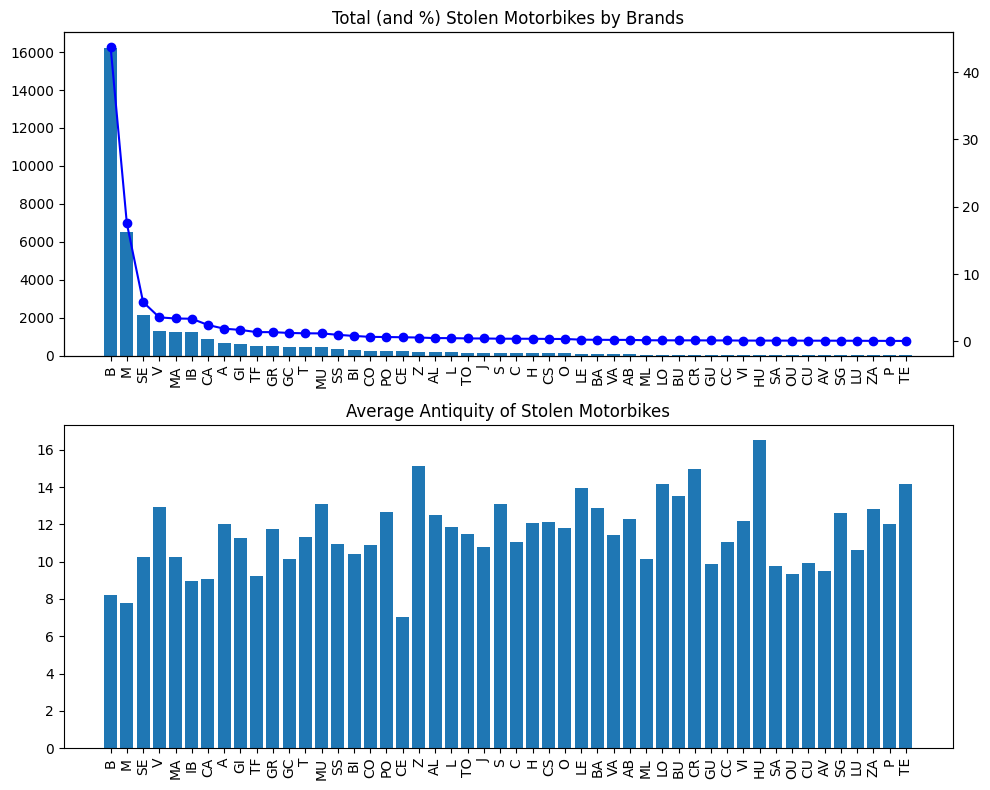

```python
# creating dataframe with the number of stolen motorbikes and the antiquity per Province
df_prov = df.groupby('province')['years_to_stole'].agg(["count", "mean"]).reset_index().sort_values(by="count", ascending=False).rename(columns={"count":"stolen_complete", "mean":"average_years_to_stole"})
df_stolen_2021 = df[(df["stolen_date"]<=pd.to_datetime('2021-11-30')) & (df["stolen_year"]==2021)]

df_stolen_2021_prov = pd.DataFrame(df_stolen_2021["province"].value_counts()).reset_index().rename(columns={"count":"stolen_2021"})
df_stolen_2022_prov = pd.DataFrame(df_stolen_2022["province"].value_counts()).reset_index().rename(columns={"count":"stolen_2022"})

df_prov = pd.merge(df_prov, df_stolen_2021_prov, on="province", how="inner")
df_prov = pd.merge(df_prov, df_stolen_2022_prov, on="province", how="inner")

df_prov["growth"] = ((df_prov["stolen_2022"] - df_prov["stolen_2021"]) / df_prov["stolen_2021"]) * 100
df_prov = df_prov.sort_values(by="stolen_complete", ascending=False)

df_prov["percentage_ratio_all"] = (df_prov["stolen_complete"] / np.sum(df_prov["stolen_complete"])) * 100

plot_count_and_average_antiquity_by_dimension(df_prov, dimension="province", value1="stolen_complete", value2="percentage_ratio_all", value3="average_years_to_stole")
```

As we can see, the province with the highest number of motorcycle thefts is **Barcelona**, followed by **Madrid** and **Seville**. This makes complete sense, as Barcelona has the highest concentration of motorcycles.

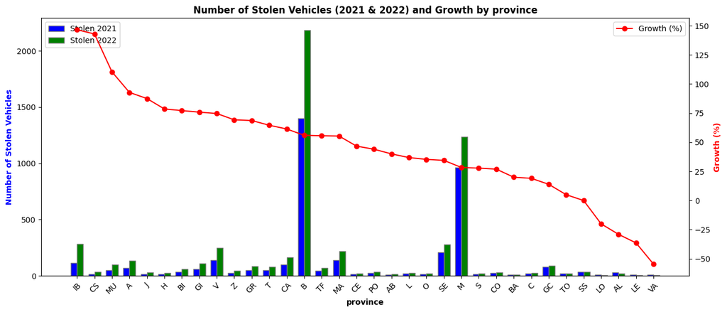

```python
df_prov_sorted = df_prov.sort_values(by="growth", ascending=False)

plot_count_and_growth_by_dimension(df_prov_sorted[df_prov_sorted["stolen_2021"]>=10], dimension="province")
```

As shown in the previous chart, although Barcelona and Madrid have the highest number of thefts and a significant growth rate, the **Balearic Islands also present a big amount of them**. This may be due to the increase in leisure and tourism in 2022 following the easing of pandemic restrictions.

This indicates that the M business department should focus on acquiring customers for the functionality in Barcelona and Madrid, but it would also be a good idea to **target audiences in the Balearic Islands, particularly motorcycle rental agencies**.

Thinking about users and the M functionality, I wouldn't focus on the province. I will be better if we think about smaller areas within the cities, such as the census section. This way, a **user could be informed if they have left their motorcycle in an area where the theft rate is higher than the city's average, or suggest safer areas to park**.

## Conclusions

The analysis of stolen motorbikes in Spain reveals several key patterns and insights that can inform strategic decisions for the M business team:

1. Although the situation with motorcycle thefts is slightly better than it was 5 years ago, there has been a significant increase in thefts currently (in 2022), and although this may be due to the pandemic and the restrictions of 2021, all indications are that in 2023, **users' concerns about the safety of their motorbikes will increase**.
2. The more motorcycle movement there is, the more thefts occur, especially if these **movements** are **for commuting from home to work**.
3. Honda is the brand most frequently targeted by thieves, followed by Yamaha and Kymco, with SYM showing a significant rise in thefts, reflecting its growing market presence. Therefore, **it would be a good idea to focus on these brands for business development.**
4. Newer motorbikes (0-2 years old) are stolen less often, possibly due to pandemic-era sales drops and heightened user vigilance, thefts are more common among 2-3-year-old models and increase sharply for those over 10 years old, likely due to outdated anti-theft measures. **Therefore, it would be beneficial not only to develop a feature for new motorbikes but also to adapt it for older models.**
5. Geographically, Barcelona, Madrid, and Seville experience the highest theft rates, reflecting high concentrations of motorbikes, while the Balearic Islands show a concerning rise potentially linked to increased tourism post-pandemic. **That’s why the M team should focus on these high-demand areas**.
6. It would be great to implement a **feature where the user could be informed if they have parked their motorcycle in an area where the theft rate is higher than the city's average or suggest safer areas to park**.

Although we don't have the **Market Share data** for motorbikes in Spain, **we have been able to draw conclusions and insights that can help with decision-making for both the business department and the development team at M**.